# Topic-6

TA Kiran

2023-10-14

```r
# Set the Working Directory:
setwd("D:/TA Introducing the data Science/2023 notes/Topic-6")

#Get Current Working Directory
getwd()
```

```
## [1] "D:/TA Introducing the data Science/2023 notes/Topic-6"
```

# Reading the dataset

```r
autos=read.csv('autos.csv')
str(autos)
```

```
## 'data.frame':    193 obs. of  24 variables:
##  $ make             : chr  "alfa-romero" "alfa-romero" "alfa-romero" "audi" ...
##  $ fuel.type        : chr  "gas" "gas" "gas" "gas" ...
##  $ aspiration       : chr  "std" "std" "std" "std" ...
##  $ num.doors        : int  2 2 2 4 4 2 4 4 4 2 ...
##  $ body.style       : chr  "convertible" "convertible" "hatchback" "sedan" ...
##  $ drive.wheels     : chr  "rwd" "rwd" "rwd" "fwd" ...
##  $ engine.location  : chr  "front" "front" "front" "front" ...
##  $ wheel.base       : num  88.6 88.6 94.5 99.8 99.4 ...
##  $ length           : num  169 169 171 177 177 ...
##  $ width            : num  64.1 64.1 65.5 66.2 66.4 66.3 71.4 71.4 71.4 64.8 ...
##  $ height           : num  48.8 48.8 52.4 54.3 54.3 53.1 55.7 55.7 55.9 54.3 ...
##  $ curb.weight      : int  2548 2548 2823 2337 2824 2507 2844 2954 3086 2395 ...
##  $ engine.type      : chr  "dohc" "dohc" "ohcv" "ohc" ...
##  $ num.cylinders    : int  4 4 6 4 5 5 5 5 5 4 ...
##  $ engine.size      : int  130 130 152 109 136 136 136 136 131 108 ...
##  $ fuel.system      : chr  "mpfi" "mpfi" "mpfi" "mpfi" ...
##  $ bore             : num  3.47 3.47 2.68 3.19 3.19 3.19 3.19 3.19 3.13 3.5 ...
##  $ stroke           : num  2.68 2.68 3.47 3.4 3.4 3.4 3.4 3.4 3.4 2.8 ...
##  $ compression.ratio: num  9 9 9 10 8 8.5 8.5 8.5 8.3 8.8 ...
##  $ horsepower       : int  111 111 154 102 115 110 110 110 140 101 ...
##  $ peak.rpm         : int  5000 5000 5000 5500 5500 5500 5500 5500 5500 5800 ...
##  $ city.mpg         : int  21 21 19 24 18 19 19 19 17 23 ...
##  $ highway.mpg      : int  27 27 26 30 22 25 25 25 20 29 ...
##  $ price            : int  13495 16500 16500 13950 17450 15250 17710 18920 23875 16430 ...
```

```r
summary(autos)
```

```
##      make            fuel.type          aspiration          num.doors
##  Length:193         Length:193         Length:193         Min.   :2.000
##  Class :character   Class :character   Class :character   1st Qu.:2.000
##  Mode  :character   Mode  :character   Mode  :character   Median :4.000
##                                                           Mean   :3.161
##                                                           3rd Qu.:4.000
##                                                           Max.   :4.000
##   body.style        drive.wheels       engine.location      wheel.base
##  Length:193         Length:193         Length:193         Min.   : 86.60
##  Class :character   Class :character   Class :character   1st Qu.: 94.50
##  Mode  :character   Mode  :character   Mode  :character   Median : 97.00
##                                                           Mean   : 98.92
##                                                           3rd Qu.:102.40
##                                                           Max.   :120.90
##      length          width           height       curb.weight
##  Min.   :141.1   Min.   :60.30   Min.   :47.80   Min.   :1488
##  1st Qu.:166.3   1st Qu.:64.10   1st Qu.:52.00   1st Qu.:2145
##  Median :173.2   Median :65.40   Median :54.10   Median :2414
##  Mean   :174.3   Mean   :65.89   Mean   :53.87   Mean   :2562
##  3rd Qu.:184.6   3rd Qu.:66.90   3rd Qu.:55.70   3rd Qu.:2952
##  Max.   :208.1   Max.   :72.00   Max.   :59.80   Max.   :4066
##  engine.type        num.cylinders    engine.size    fuel.system
##  Length:193         Min.   : 3.00   Min.   : 61.0   Length:193
##  Class :character   1st Qu.: 4.00   1st Qu.: 98.0   Class :character
##  Mode  :character   Median : 4.00   Median :120.0   Mode  :character
##                     Mean   : 4.42   Mean   :128.1
##                     3rd Qu.: 4.00   3rd Qu.:146.0
##                     Max.   :12.00   Max.   :326.0
##       bore           stroke      compression.ratio   horsepower
##  Min.   :2.540   Min.   :2.070   Min.   : 7.00     Min.   : 48.0
##  1st Qu.:3.150   1st Qu.:3.110   1st Qu.: 8.50     1st Qu.: 70.0
##  Median :3.310   Median :3.290   Median : 9.00     Median : 95.0
##  Mean   :3.331   Mean   :3.249   Mean   :10.14     Mean   :103.5
##  3rd Qu.:3.590   3rd Qu.:3.410   3rd Qu.: 9.40     3rd Qu.:116.0
##  Max.   :3.940   Max.   :4.170   Max.   :23.00     Max.   :262.0
##     peak.rpm       city.mpg      highway.mpg        price
##  Min.   :4150   Min.   :13.00   Min.   :16.00   Min.   : 5118
##  1st Qu.:4800   1st Qu.:19.00   1st Qu.:25.00   1st Qu.: 7738
##  Median :5100   Median :25.00   Median :30.00   Median :10245
##  Mean   :5100   Mean   :25.33   Mean   :30.79   Mean   :13285
##  3rd Qu.:5500   3rd Qu.:30.00   3rd Qu.:34.00   3rd Qu.:16515
##  Max.   :6600   Max.   :49.00   Max.   :54.00   Max.   :45400
```

```r
library(psych)
describe(autos) #describe() can computes the statistics of all numerical variables in data:
```

```
##                   vars   n     mean      sd   median  trimmed     mad     min
## make*                1 193    13.04    5.90    13.00    13.41    8.90    1.00
## fuel.type*           2 193     1.90    0.30     2.00     2.00    0.00    1.00
## aspiration*          3 193     1.18    0.39     1.00     1.10    0.00    1.00
## num.doors            4 193     3.16    0.99     4.00     3.20    0.00    2.00
## body.style*          5 193     3.62    0.87     4.00     3.66    1.48    1.00
## drive.wheels*        6 193     2.33    0.55     2.00     2.34    0.00    1.00
## engine.location*     7 193     1.02    0.12     1.00     1.00    0.00    1.00
## wheel.base           8 193    98.92    6.15    97.00    98.28    4.89   86.60
## length               9 193   174.33   12.48   173.20   174.08   10.38  141.10
## width               10 193    65.89    2.14    65.40    65.65    2.08   60.30
## height              11 193    53.87    2.39    54.10    53.85    2.37   47.80
## curb.weight         12 193  2561.51  526.70  2414.00  2518.30  578.21 1488.00
## engine.type*        13 193     3.03    0.81     3.00     3.03    0.00    1.00
## num.cylinders       14 193     4.42    1.02     4.00     4.19    0.00    3.00
## engine.size         15 193   128.12   41.59   120.00   121.45   32.62   61.00
## fuel.system*        16 193     3.63    1.58     5.00     3.66    1.48    1.00
## bore                17 193     3.33    0.27     3.31     3.33    0.39    2.54
## stroke              18 193     3.25    0.32     3.29     3.27    0.25    2.07
## compression.ratio   19 193    10.14    3.98     9.00     9.02    0.59    7.00
## horsepower          20 193   103.48   37.96    95.00    98.92   37.06   48.00
## peak.rpm            21 193  5099.74  468.69  5100.00  5102.90  444.78 4150.00
## city.mpg            22 193    25.33    6.39    25.00    24.95    7.41   13.00
## highway.mpg         23 193    30.79    6.82    30.00    30.50    7.41   16.00
## price               24 193 13285.03 8089.08 10245.00 11732.67 4932.61 5118.00
##                        max   range  skew kurtosis     se
## make*                21.00    20.0 -0.40    -1.09   0.42
## fuel.type*            2.00     1.0 -2.67     5.18   0.02
## aspiration*           2.00     1.0  1.64     0.70   0.03
## num.doors             4.00     2.0 -0.32    -1.91   0.07
## body.style*           5.00     4.0 -0.70     0.95   0.06
## drive.wheels*         3.00     2.0 -0.03    -0.72   0.04
## engine.location*      2.00     1.0  7.77    58.70   0.01
## wheel.base          120.90    34.3  0.96     0.71   0.44
## length              208.10    67.0  0.14    -0.18   0.90
## width                72.00    11.7  0.85     0.48   0.15
## height               59.80    12.0  0.03    -0.37   0.17
## curb.weight        4066.00  2578.0  0.66    -0.15  37.91
## engine.type*          5.00     4.0  0.01     2.06   0.06
## num.cylinders        12.00     9.0  3.39    16.47   0.07
## engine.size         326.00   265.0  1.98     5.25   2.99
## fuel.system*          7.00     6.0 -0.13    -1.59   0.11
## bore                  3.94     1.4 -0.03    -0.89   0.02
## stroke                4.17     2.1 -0.74     1.99   0.02
## compression.ratio    23.00    16.0  2.56     4.93   0.29
## horsepower          262.00   214.0  1.12     1.10   2.73
## peak.rpm           6600.00  2450.0  0.10     0.17  33.74
## city.mpg             49.00    36.0  0.66     0.74   0.46
## highway.mpg          54.00    38.0  0.53     0.52   0.49
## price             45400.00 40282.0  1.73     2.81 582.26
```

**Simple Linear Regression with intercept**

```r
#Simple linear regression using the lm() function
model=lm(price~horsepower,data=autos)
summary(model)
```

```
##
## Call:
## lm(formula = price ~ horsepower, data = autos)
##
## Residuals:
##      Min       1Q   Median       3Q      Max
## -10296.1  -2243.5   -450.1   1794.7  18174.9
##
## Coefficients:
##             Estimate Std. Error t value Pr(>|t|)
## (Intercept) -4630.70     990.58  -4.675 5.55e-06 ***
## horsepower    173.13       8.99  19.259  < 2e-16 ***
## ---
## Signif. codes:  0 '***' 0.001 '**' 0.01 '*' 0.05 '.' 0.1 ' ' 1
##
## Residual standard error: 4728 on 191 degrees of freedom
## Multiple R-squared:  0.6601, Adjusted R-squared:  0.6583
## F-statistic: 370.9 on 1 and 191 DF,  p-value: < 2.2e-16
```

```r
coef(model)
```

```
## (Intercept)  horsepower
##  -4630.7022    173.1292
```

```r
confint(model)
```

```
##                  2.5 %     97.5 %
## (Intercept) -6584.5789 -2676.8255
## horsepower    155.3974   190.8609
```

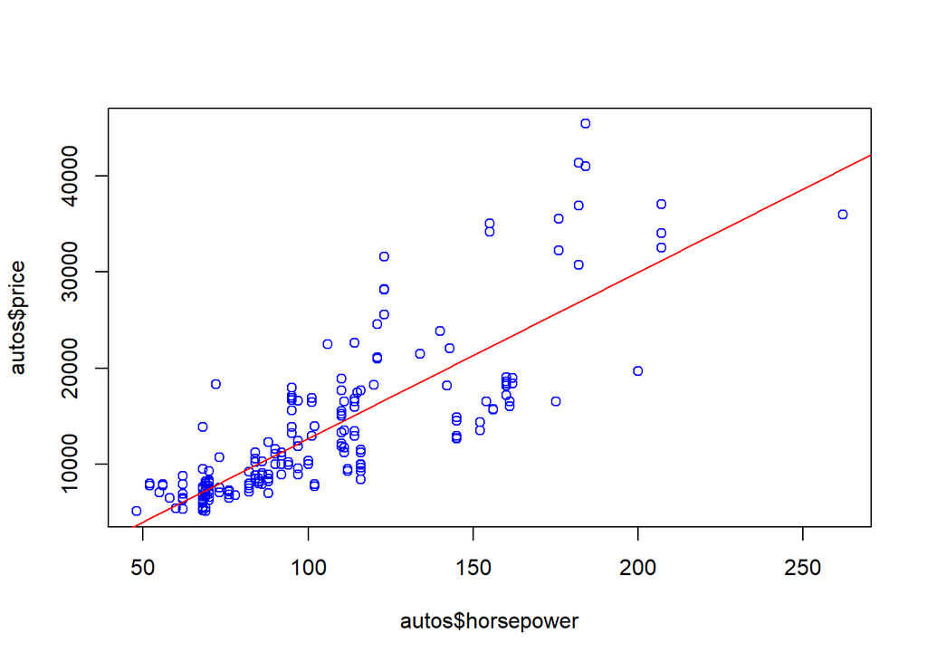

```r
plot(autos$horsepower,autos$price,col="blue")
abline(model,col="red")
```

```r
residuals(model) #residuals(or errors) represent the difference between the actual values of the dependent variable (Y) and the predicted values from the model.
```

```
##            1            2            3            4            5            6
##  -1091.63423   1913.36577  -5531.18797    921.52818   2170.84914    836.49493
##            7            8            9           10           11           12
##   3296.49493   4506.49493   4267.62022   3574.65734   4069.65734   4652.07420
##           13           14           15           16           17           18
##   4787.07420   8247.07420   3881.19564  14436.19564  10001.19564   1471.50265
##           19           20           21           22           23           24
##  -1193.33880   -913.33880  -1570.08049   -765.08049  -5071.47182   -913.08049
##           25           26           27           28           29           30
##   -450.08049    466.91951  -1683.66362  -7509.02556   1068.21108  -1672.11374
##           31           32           33           34           35           36
##   -358.04723  -1998.11374  -1398.11374  -1232.11374  -1232.11374  -2363.40531
##           37           38           39           40           41           42
##  -1163.40531  -1413.40531     36.59469     89.65734  -2337.21351  -2088.37206
##           43           44           45           46           47           48
##     97.07806   6409.97058   9709.97058  -4729.13691  -1947.08049  -1047.08049
##           49           50           51           52           53           54
##   -347.08049   -447.08049    252.91951  -1067.14700  -1417.14700    682.85300
##           55           56           57           58           59           60
##    332.85300   1332.85300   2135.20336  10509.40288   8887.81589  11583.81589
##           61           62           63           64           65           66
##  11511.81589  14935.81589  11979.68287  12851.68287  13734.93732  18174.93732
##           67           68           69           70           71           72
##  -9163.90027  -1753.08049   -953.08049   -473.08049  -5339.47182  -5493.28001
##           73           74           75           76           77           78
##  -2105.66362  -7844.02556  -5604.02556  -5984.02556  -3615.66362  -2415.66362
##           79           80           81           82           83           84
##  -6173.28001  -6173.28001  -1816.20964   2207.59855   -666.20964   -466.20964
##           85           86           87           88           89           90
##     33.79036    -16.20964    483.79036    183.79036    683.79036    933.79036
##           91           92           93           94           95           96
##  -3213.82604  -2613.82604  -8185.92966  -7285.92966  -8185.92966  -5870.96291
##           97           98           99          100          101          102
## -10296.12919  -4670.96291   -262.82604   1383.43228    277.17396   2043.43228
##          103          104          105          106          107          108
##   3763.43228   5083.43228   4878.43228   5258.43228   4467.17396   6133.43228
##          109          110          111          112          113          114
##  -1803.63809  -1570.08049  -5071.47182   -913.08049   -450.08049    466.91951
##          115          116          117          118          119          120
##  -1683.66362  -7709.02556   1891.23275   1320.96672   2820.96672   5820.96672
```

[output cut: 11 more lines]

```
##   1769.66120    569.66120    749.66120  -5461.76339  -5221.76339  -7003.28001
##          157          158          159          160          161          162
##  -5813.28001  -5463.28001  -4253.28001  -3903.28001   2216.71999  -2349.18025
##          163          164          165          166          167          168
##   2690.27373  -1309.18025   -399.18025    -49.18025  -6685.09207  -7245.09207
##          169          170          171          172          173          174
##  -6687.44629  -6627.44629   3402.98602  -2110.27615   3622.98602  -1890.27615
##          175          176          177          178          179          180
##  -1590.27615   2352.91951  -2687.21351    644.07806   -970.92194  -1118.50507
##          181          182          183          184          185          186
##   6702.91951   1685.33638  -2166.02170  -1691.02170    878.97830   1408.97830
##          187          188          189          190          191          192
##  -4996.22123  -4466.22123   1738.97830  -4024.96291   2916.39516   8749.01155
##          193
##   7518.97830
```

**Checking for the Normality of the Residuals (or error)**

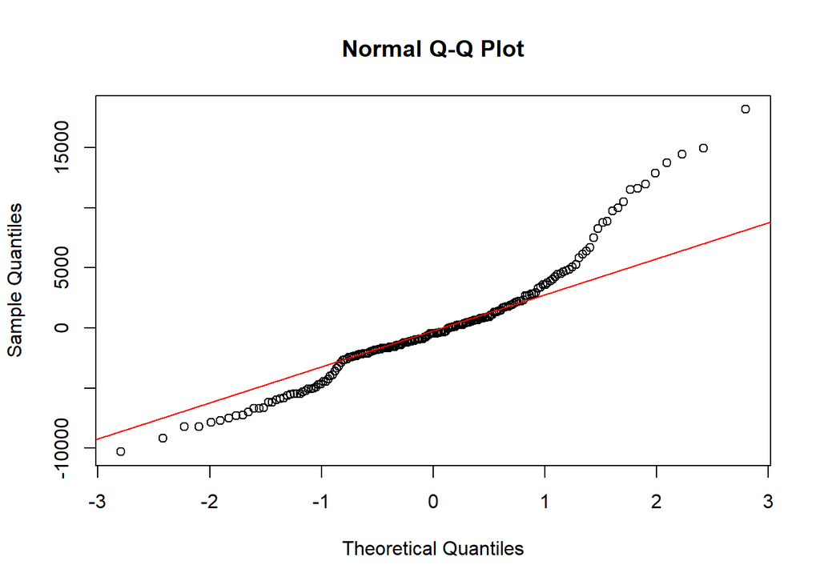

```r
#normality of the residuals from a linear regression model
qqnorm(residuals(model))
qqline(residuals(model),col='red')
```

```r
ks.test(residuals(model),"pnorm")
```

```
##
##  Asymptotic one-sample Kolmogorov-Smirnov test
##
## data:  residuals(model)
## D = 0.55959, p-value < 2.2e-16
## alternative hypothesis: two-sided
```

Note:- Normally Distributed Residuals: The assumption is that the residuals follow a normal distribution. This assumption is important because it helps to ensure that the estimates of the regression coefficients (slope and intercept) are unbiased and efficient, and it’s a key assumption for conducting hypothesis tests and constructing confidence intervals.

```r
# predict the model
predict(model)
```

```
##         1         2         3         4         5         6         7         8
## 14586.634 14586.634 22031.188 13028.472 15279.151 14413.505 14413.505 14413.505
##         9        10        11        12        13        14        15        16
## 19607.380 12855.343 12855.343 16317.926 16317.926 16317.926 26878.804 26878.804
##        17        18        19        20        21        22        23        24
## 26878.804  3679.497  7488.339  7488.339  7142.080  7142.080 13028.472  7142.080
##        25        26        27        28        29        30        31        32
##  7142.080  7142.080 10604.664 20473.026  5410.789  8527.114  5757.047  8527.114
##        33        34        35        36        37        38        39        40
##  8527.114  8527.114  8527.114 10258.405 10258.405 10258.405 10258.405 12855.343
##        41        42        43        44        45        46        47        48
## 12682.214  8873.372 10950.922 25840.029 25840.029 40729.137  7142.080  7142.080
##        49        50        51        52        53        54        55        56
##  7142.080  7142.080  7142.080  9912.147  9912.147  9912.147  9912.147  9912.147
##        57        58        59        60        61        62        63        64
## 16144.797  7834.597 16664.184 16664.184 16664.184 16664.184 22204.317 22204.317
##        65        66        67        68        69        70        71        72
## 27225.063 27225.063 25666.900  7142.080  7142.080  7142.080 13028.472 15452.280
##        73        74        75        76        77        78        79        80
## 10604.664 20473.026 20473.026 20473.026 10604.664 10604.664 15452.280 15452.280
##        81        82        83        84        85        86        87        88
##  7315.210  4891.401  7315.210  7315.210  7315.210  7315.210  7315.210  7315.210
##        89        90        91        92        93        94        95        96
##  7315.210  7315.210 12162.826 12162.826 21684.930 21684.930 21684.930 23069.963
##        97        98        99       100       101       102       103       104
## 29995.129 23069.963 12162.826 11816.568 12162.826 11816.568 11816.568 11816.568
##       105       106       107       108       109       110       111       112
## 11816.568 11816.568 12162.826 11816.568 19953.638  7142.080 13028.472  7142.080
##       113       114       115       116       117       118       119       120
##  7142.080  7142.080 10604.664 20473.026 20126.767 31207.033 31207.033 31207.033
##       121       122       123       124       125       126       127       128
## 14413.505 14413.505 14413.505 14413.505 23069.963 23069.963  7315.210  8007.726
##       129       130       131       132       133       134       135       136
##  8007.726  9565.889  9565.889 11643.439  9565.889 14586.634  9565.889 11643.439
##       137       138       139       140       141       142       143       144
##  9565.889 14586.634  6103.306  6103.306  6103.306  6103.306  6103.306  6103.306
##       145       146       147       148       149       150       151       152
##  7488.339  7488.339  5064.531  5064.531  7488.339  7488.339  7488.339  7488.339
##       153       154       155       156       157       158       159       160
##  7488.339 14759.763 14759.763 15452.280 15452.280 15452.280 15452.280 15452.280
##       161       162       163       164       165       166       167       168
## 15452.280 11297.180  8007.726 11297.180 11297.180 11297.180 23243.092 23243.092
##       169       170       171       172       173       174       175       176
## 22377.446 22377.446  4372.014 10085.276  4372.014 10085.276 10085.276  7142.080
##       177       178       179       180       181       182       183       184
## 12682.214 10950.922 10950.922 14413.505  7142.080 10604.664 15106.022 15106.022
##       185       186       187       188       189       190       191       192
## 15106.022 15106.022 23416.221 23416.221 15106.022 23069.963 18568.605 13720.988
##       193
## 15106.022
```

```r
# predicting the value for new dataset
new.data = data.frame(horsepower = c(100,125,150,175,200))
predict(model,new.data)
```

```
##        1        2        3        4        5
## 12682.21 17010.44 21338.67 25666.90 29995.13
```

**Polynomial regression**

```r
library("ggplot2")
#2nd-Degree Polynomial Regression:
# Fit a 2nd-degree polynomial regression model
model_2nd_degree <- lm(price ~ poly(horsepower, 2, raw = TRUE),data=autos)
model_2nd_degree
```

```
##
## Call:
## lm(formula = price ~ poly(horsepower, 2, raw = TRUE), data = autos)
##
## Coefficients:
##                      (Intercept)  poly(horsepower, 2, raw = TRUE)1
##                        -2357.924                           131.690
## poly(horsepower, 2, raw = TRUE)2
##                            0.166
```

```r
# Display the summary of the 2nd-degree polynomial regression model
summary(model_2nd_degree)
```

```
##
## Call:
## lm(formula = price ~ poly(horsepower, 2, raw = TRUE), data = autos)
##
## Residuals:
##      Min       1Q   Median       3Q      Max
## -10920.6  -2169.5   -672.5   1773.8  17907.3
##
## Coefficients:
##                                    Estimate Std. Error t value Pr(>|t|)
## (Intercept)                      -2357.9241  2572.4712  -0.917  0.36051
## poly(horsepower, 2, raw = TRUE)1   131.6898    44.2092   2.979  0.00327 **
## poly(horsepower, 2, raw = TRUE)2     0.1660     0.1734   0.957  0.33960
## ---
## Signif. codes:  0 '***' 0.001 '**' 0.01 '*' 0.05 '.' 0.1 ' ' 1
##
## Residual standard error: 4730 on 190 degrees of freedom
## Multiple R-squared:  0.6617, Adjusted R-squared:  0.6582
## F-statistic: 185.8 on 2 and 190 DF,  p-value: < 2.2e-16
```

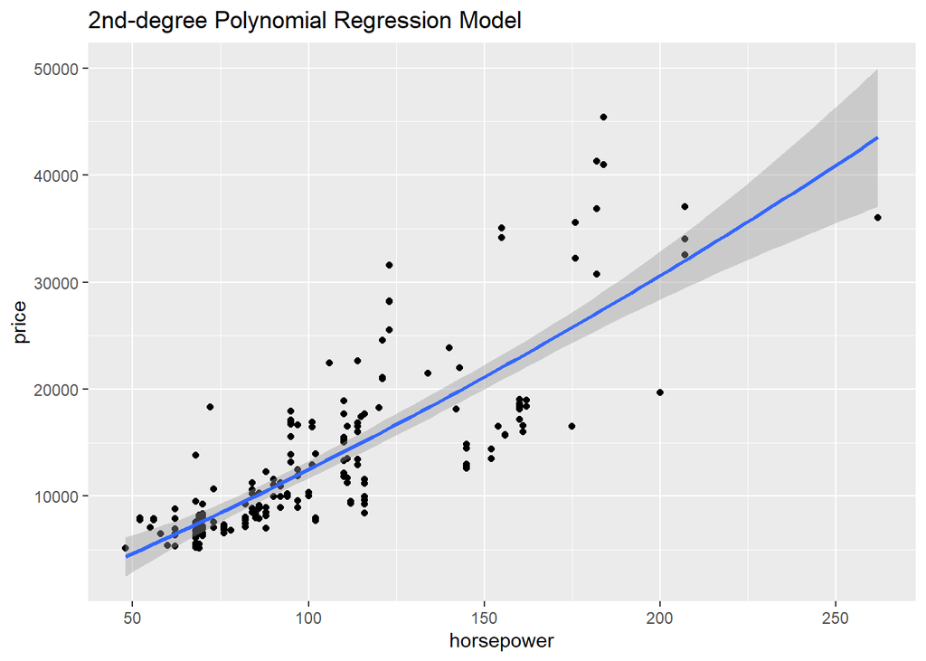

```r
#predict(model_2nd_degree)
ggplot(autos, aes(horsepower, price) ) + geom_point() +
stat_smooth(method = lm, formula = y ~ poly(x, 2, raw = TRUE))+ggtitle("2nd-degree Polynomial Regression Model")
```

```r
# Fit a 3rd-degree polynomial regression model
model_3rd_degree <- lm(price ~ poly(horsepower, 3, raw = TRUE),data=autos)

# Display the summary of the 3rd-degree polynomial regression model
summary(model_3rd_degree)
```

```
##
## Call:
## lm(formula = price ~ poly(horsepower, 3, raw = TRUE), data = autos)
##
## Residuals:
##      Min       1Q   Median       3Q      Max
## -11528.7  -1982.4   -743.7   1713.3  17123.8
##
## Coefficients:
##                                    Estimate Std. Error t value Pr(>|t|)
## (Intercept)                       5.899e+03  6.089e+03   0.969    0.334
## poly(horsepower, 3, raw = TRUE)1 -8.297e+01  1.502e+02  -0.552    0.581
## poly(horsepower, 3, raw = TRUE)2  1.846e+00  1.137e+00   1.624    0.106
## poly(horsepower, 3, raw = TRUE)3 -3.988e-03  2.668e-03  -1.495    0.137
##
## Residual standard error: 4714 on 189 degrees of freedom
## Multiple R-squared:  0.6657, Adjusted R-squared:  0.6604
## F-statistic: 125.4 on 3 and 189 DF,  p-value: < 2.2e-16
```

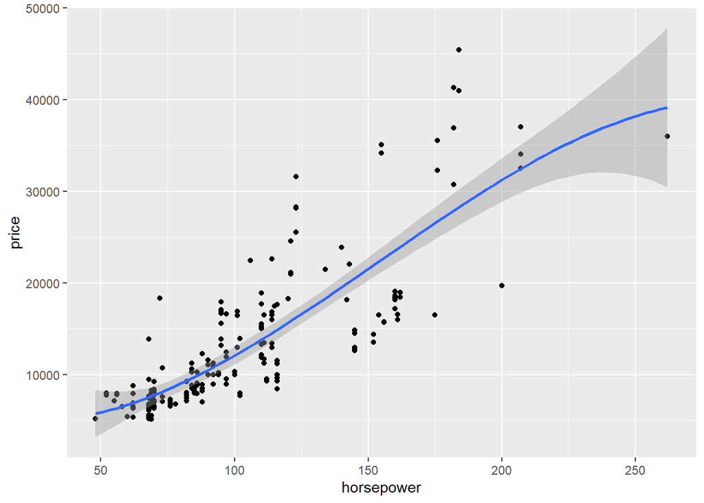

```r
#predict(model_3rd_degree)
ggplot(autos, aes(horsepower, price) ) + geom_point() +
stat_smooth(method = lm, formula = y ~ poly(x, 3, raw = TRUE))
```

```r
list('Sum of square error with intercept'=sum(residuals(model)^2),'Sum of square error with quadratic term'=sum(residuals(model_2nd_degree)^2),'Sum of square error with cubic term'=sum(residuals(model_3rd_degree)^2))
```

```
## $`Sum of square error with intercept`
## [1] 4270475650
##
## $`Sum of square error with quadratic term`
## [1] 4249974379
##
## $`Sum of square error with cubic term`
## [1] 4200309123
```

**Multiple Linear Regression**

```r
reg1=lm(price ~ length + engine.size + horsepower + city.mpg+bore+stroke+compression.ratio+peak.rpm,data=autos)
summary(model)
```

```
##
## Call:
## lm(formula = price ~ horsepower, data = autos)
##
## Residuals:
##      Min       1Q   Median       3Q      Max
## -10296.1  -2243.5   -450.1   1794.7  18174.9
##
## Coefficients:
##             Estimate Std. Error t value Pr(>|t|)
## (Intercept) -4630.70     990.58  -4.675 5.55e-06 ***
## horsepower    173.13       8.99  19.259  < 2e-16 ***
## ---
## Signif. codes:  0 '***' 0.001 '**' 0.01 '*' 0.05 '.' 0.1 ' ' 1
##
## Residual standard error: 4728 on 191 degrees of freedom
## Multiple R-squared:  0.6601, Adjusted R-squared:  0.6583
## F-statistic: 370.9 on 1 and 191 DF,  p-value: < 2.2e-16
```

**1.Backward Elimination**

```r
library(car)
reg2<-step(lm(price ~ length + engine.size + horsepower + city.mpg+bore+stroke+compression.ratio+peak.rpm,data=autos),direction="backward")
```

```
## Start:  AIC=3133.18
## price ~ length + engine.size + horsepower + city.mpg + bore +
##     stroke + compression.ratio + peak.rpm
##
##                     Df  Sum of Sq        RSS    AIC
## - bore               1    6246147 1980586559 3131.8
## - city.mpg           1    7075193 1981415606 3131.9
## <none>                            1974340413 3133.2
## - horsepower         1   36176845 2010517258 3134.7
## - length             1   62389795 2036730207 3137.2
## - peak.rpm           1   94977259 2069317672 3140.2
## - stroke             1  136348912 2110689325 3144.1
## - compression.ratio  1  175992493 2150332906 3147.7
## - engine.size        1 1015372947 2989713360 3211.3
##
## Step:  AIC=3131.79
## price ~ length + engine.size + horsepower + city.mpg + stroke +
##     compression.ratio + peak.rpm
##
##                     Df  Sum of Sq        RSS    AIC
## - city.mpg           1    5639706 1986226265 3130.3
## <none>                            1980586559 3131.8
## - horsepower         1   31928351 2012514910 3132.9
## - length             1   57347349 2037933908 3135.3
## - peak.rpm           1  120297694 2100884253 3141.2
## - stroke             1  130159873 2110746432 3142.1
## - compression.ratio  1  175657172 2156243731 3146.2
## - engine.size        1 1021319376 3001905935 3210.0
##
## Step:  AIC=3130.33
## price ~ length + engine.size + horsepower + stroke + compression.ratio +
##     peak.rpm
##
##                     Df  Sum of Sq        RSS    AIC
## <none>                            1986226265 3130.3
## - horsepower         1   63626228 2049852493 3134.4
## - peak.rpm           1  119721107 2105947373 3139.6
## - length             1  129381678 2115607943 3140.5
## - stroke             1  132144153 2118370419 3140.8
## - compression.ratio  1  190178031 2176404296 3146.0
## - engine.size        1 1015680154 3001906420 3208.0
```

```r
summary(reg2)
```

```
##
## Call:
## lm(formula = price ~ length + engine.size + horsepower + stroke +
##     compression.ratio + peak.rpm, data = autos)
##
## Residuals:
##      Min       1Q   Median       3Q      Max
## -12850.0  -1739.0     65.4   1485.4  12833.6
##
## Coefficients:
##                     Estimate Std. Error t value Pr(>|t|)
## (Intercept)       -2.937e+04  6.239e+03  -4.708 4.88e-06 ***
## length             9.446e+01  2.714e+01   3.481 0.000623 ***
## engine.size        1.350e+02  1.384e+01   9.753  < 2e-16 ***
## horsepower         3.574e+01  1.464e+01   2.441 0.015585 *
## stroke            -2.779e+03  7.900e+02  -3.518 0.000547 ***
## compression.ratio  2.970e+02  7.038e+01   4.220 3.81e-05 ***
## peak.rpm           2.198e+00  6.566e-01   3.348 0.000984 ***
## ---
## Signif. codes:  0 '***' 0.001 '**' 0.01 '*' 0.05 '.' 0.1 ' ' 1
##
## Residual standard error: 3268 on 186 degrees of freedom
## Multiple R-squared:  0.8419, Adjusted R-squared:  0.8368
## F-statistic: 165.1 on 6 and 186 DF,  p-value: < 2.2e-16
```

**2.Forward Selection**

```r
reg3<-step(lm( price~1,data=autos),direction="forward",scope=~length + engine.size + horsepower + city.mpg+bore+stroke+compression.ratio+peak.rpm)
```

```
## Start:  AIC=3474.33
## price ~ 1
##
##                     Df  Sum of Sq        RSS    AIC
## + engine.size        1 9924002742 2.6392e+09 3175.2
## + horsepower         1 8292710641 4.2705e+09 3268.1
## + city.mpg           1 6272911842 6.2903e+09 3342.8
## + length             1 6084547887 6.4786e+09 3348.5
## + bore               1 3749338814 8.8138e+09 3407.9
## + peak.rpm           1  135453411 1.2428e+10 3474.2
## <none>                            1.2563e+10 3474.3
## + stroke             1  115798447 1.2447e+10 3474.5
## + compression.ratio  1   69696287 1.2493e+10 3475.3
##
## Step:  AIC=3175.19
## price ~ engine.size
##
##                     Df Sum of Sq        RSS    AIC
## + length             1 173274511 2465909037 3164.1
## + horsepower         1 164570191 2474613358 3164.8
## + city.mpg           1 126156014 2513027535 3167.7
## + stroke             1 117983472 2521200077 3168.4
## + peak.rpm           1 106148224 2533035325 3169.3
## + compression.ratio  1  34038076 2605145473 3174.7
## <none>                           2639183549 3175.2
## + bore               1  16145906 2623037643 3176.0
##
## Step:  AIC=3164.09
## price ~ engine.size + length
##
##                     Df Sum of Sq        RSS    AIC
## + peak.rpm           1 165320787 2300588250 3152.7
## + horsepower         1 156989612 2308919426 3153.4
## + stroke             1 108078172 2357830866 3157.4
## + city.mpg           1  40323907 2425585130 3162.9
## <none>                           2465909037 3164.1
## + compression.ratio  1  11444372 2454464666 3165.2
## + bore               1    389109 2465519929 3166.1
##
## Step:  AIC=3152.69
```

[output cut: 22 more lines]

```
##
##              Df Sum of Sq        RSS    AIC
## + horsepower  1  63626228 1986226265 3130.3
## + city.mpg    1  37337583 2012514910 3132.9
## <none>                    2049852493 3134.4
## + bore        1     10723 2049841770 3136.4
##
## Step:  AIC=3130.33
## price ~ engine.size + length + peak.rpm + stroke + compression.ratio +
##     horsepower
##
##            Df Sum of Sq        RSS    AIC
## <none>                  1986226265 3130.3
## + city.mpg  1   5639706 1980586559 3131.8
## + bore      1   4810660 1981415606 3131.9
```

```r
summary(reg2)
```

```
##
## Call:
## lm(formula = price ~ length + engine.size + horsepower + stroke +
##     compression.ratio + peak.rpm, data = autos)
##
## Residuals:
##      Min       1Q   Median       3Q      Max
## -12850.0  -1739.0     65.4   1485.4  12833.6
##
## Coefficients:
##                     Estimate Std. Error t value Pr(>|t|)
## (Intercept)       -2.937e+04  6.239e+03  -4.708 4.88e-06 ***
## length             9.446e+01  2.714e+01   3.481 0.000623 ***
## engine.size        1.350e+02  1.384e+01   9.753  < 2e-16 ***
## horsepower         3.574e+01  1.464e+01   2.441 0.015585 *
## stroke            -2.779e+03  7.900e+02  -3.518 0.000547 ***
## compression.ratio  2.970e+02  7.038e+01   4.220 3.81e-05 ***
## peak.rpm           2.198e+00  6.566e-01   3.348 0.000984 ***
## ---
## Signif. codes:  0 '***' 0.001 '**' 0.01 '*' 0.05 '.' 0.1 ' ' 1
##
## Residual standard error: 3268 on 186 degrees of freedom
## Multiple R-squared:  0.8419, Adjusted R-squared:  0.8368
## F-statistic: 165.1 on 6 and 186 DF,  p-value: < 2.2e-16
```

**3.Stepwise Regression**

```r
reg4<-step(lm(price~length + engine.size + horsepower + city.mpg+bore+stroke+compression.ratio+peak.rpm,,data=autos),direction="both")
```

```
## Start:  AIC=3133.18
## price ~ length + engine.size + horsepower + city.mpg + bore +
##     stroke + compression.ratio + peak.rpm
##
##                     Df  Sum of Sq        RSS    AIC
## - bore               1    6246147 1980586559 3131.8
## - city.mpg           1    7075193 1981415606 3131.9
## <none>                            1974340413 3133.2
## - horsepower         1   36176845 2010517258 3134.7
## - length             1   62389795 2036730207 3137.2
## - peak.rpm           1   94977259 2069317672 3140.2
## - stroke             1  136348912 2110689325 3144.1
## - compression.ratio  1  175992493 2150332906 3147.7
## - engine.size        1 1015372947 2989713360 3211.3
##
## Step:  AIC=3131.79
## price ~ length + engine.size + horsepower + city.mpg + stroke +
##     compression.ratio + peak.rpm
##
##                     Df  Sum of Sq        RSS    AIC
## - city.mpg           1    5639706 1986226265 3130.3
## <none>                            1980586559 3131.8
## - horsepower         1   31928351 2012514910 3132.9
## + bore               1    6246147 1974340413 3133.2
## - length             1   57347349 2037933908 3135.3
## - peak.rpm           1  120297694 2100884253 3141.2
## - stroke             1  130159873 2110746432 3142.1
## - compression.ratio  1  175657172 2156243731 3146.2
## - engine.size        1 1021319376 3001905935 3210.0
##
## Step:  AIC=3130.33
## price ~ length + engine.size + horsepower + stroke + compression.ratio +
##     peak.rpm
##
##                     Df  Sum of Sq        RSS    AIC
## <none>                            1986226265 3130.3
## + city.mpg           1    5639706 1980586559 3131.8
## + bore               1    4810660 1981415606 3131.9
## - horsepower         1   63626228 2049852493 3134.4
## - peak.rpm           1  119721107 2105947373 3139.6
## - length             1  129381678 2115607943 3140.5
## - stroke             1  132144153 2118370419 3140.8
## - compression.ratio  1  190178031 2176404296 3146.0
## - engine.size        1 1015680154 3001906420 3208.0
```

```r
summary(reg4)
```

```
##
## Call:
## lm(formula = price ~ length + engine.size + horsepower + stroke +
##     compression.ratio + peak.rpm, data = autos)
##
## Residuals:
##      Min       1Q   Median       3Q      Max
## -12850.0  -1739.0     65.4   1485.4  12833.6
##
## Coefficients:
##                     Estimate Std. Error t value Pr(>|t|)
## (Intercept)       -2.937e+04  6.239e+03  -4.708 4.88e-06 ***
## length             9.446e+01  2.714e+01   3.481 0.000623 ***
## engine.size        1.350e+02  1.384e+01   9.753  < 2e-16 ***
## horsepower         3.574e+01  1.464e+01   2.441 0.015585 *
## stroke            -2.779e+03  7.900e+02  -3.518 0.000547 ***
## compression.ratio  2.970e+02  7.038e+01   4.220 3.81e-05 ***
## peak.rpm           2.198e+00  6.566e-01   3.348 0.000984 ***
## ---
## Signif. codes:  0 '***' 0.001 '**' 0.01 '*' 0.05 '.' 0.1 ' ' 1
##
## Residual standard error: 3268 on 186 degrees of freedom
## Multiple R-squared:  0.8419, Adjusted R-squared:  0.8368
## F-statistic: 165.1 on 6 and 186 DF,  p-value: < 2.2e-16
```

**Summary of the all the 3 model**

```r
summary(reg2)$coef;summary(reg3)$coef;summary(reg4)$coef
```

```
##                        Estimate   Std. Error   t value     Pr(>|t|)
## (Intercept)       -29374.179258 6239.2705930 -4.707951 4.877432e-06
## length                94.460278   27.1375550  3.480795 6.228816e-04
## engine.size          135.017142   13.8442143  9.752604 2.071329e-18
## horsepower            35.738015   14.6409828  2.440957 1.558478e-02
## stroke             -2779.066569  790.0104973 -3.517759 5.469466e-04
## compression.ratio    296.991731   70.3755939  4.220096 3.813373e-05
## peak.rpm               2.198403    0.6565683  3.348324 9.840709e-04
```

```
##                        Estimate   Std. Error   t value     Pr(>|t|)
## (Intercept)       -29374.179258 6239.2705930 -4.707951 4.877432e-06
## engine.size          135.017142   13.8442143  9.752604 2.071329e-18
## length                94.460278   27.1375550  3.480795 6.228816e-04
## peak.rpm               2.198403    0.6565683  3.348324 9.840709e-04
## stroke             -2779.066569  790.0104973 -3.517759 5.469466e-04
## compression.ratio    296.991731   70.3755939  4.220096 3.813373e-05
## horsepower            35.738015   14.6409828  2.440957 1.558478e-02
```

```
##                        Estimate   Std. Error   t value     Pr(>|t|)
## (Intercept)       -29374.179258 6239.2705930 -4.707951 4.877432e-06
## length                94.460278   27.1375550  3.480795 6.228816e-04
## engine.size          135.017142   13.8442143  9.752604 2.071329e-18
## horsepower            35.738015   14.6409828  2.440957 1.558478e-02
## stroke             -2779.066569  790.0104973 -3.517759 5.469466e-04
## compression.ratio    296.991731   70.3755939  4.220096 3.813373e-05
## peak.rpm               2.198403    0.6565683  3.348324 9.840709e-04
```

**Summary of the all above model adj.r.square**

```r
summary(reg2)$adj.r.square;summary(reg3)$adj.r.square;summary(reg4)$adj.r.square;summary(reg1)$adj.r.square
```

```
## [1] 0.8368011
```

```
## [1] 0.8368011
```

```
## [1] 0.8368011
```

```
## [1] 0.8360144
```

```r
AIC(reg2);AIC(reg3);AIC(reg4);AIC(reg1)
```

```
## [1] 3680.045
```

```
## [1] 3680.045
```

```
## [1] 3680.045
```

```
## [1] 3682.887
```

**use of the Analysis of Variance (ANOVA)**

- ANOVA testing whether the more complex model is significantly better at capturing the data than the simpler model.

#Simple linear regression using the lm() function

```r
#model 1:  (only horsepower)
model1 =lm(price~horsepower,data=autos)
# # Model 2:  (horsepower AND length)
model2  = lm(price~horsepower+length,data=autos)

# Model 3:  (horsepower AND length AND bore)
model3  = lm(price~horsepower+length+bore,data=autos)
```

- compare the two simplest models: model 1 with model 2.this ANVOA will test whether or not including the length leads to a significant improvement over using just the horsepower.

```r
# Compare model 1 to model 2
anova(model1, model2)
```

```
## Analysis of Variance Table
##
## Model 1: price ~ horsepower
## Model 2: price ~ horsepower + length
##   Res.Df        RSS Df Sum of Sq      F  Pr(>F)
## 1    191 4270475650
## 2    190 3364697360  1 905778290 51.148 1.8e-11 ***
## ---
## Signif. codes:  0 '***' 0.001 '**' 0.01 '*' 0.05 '.' 0.1 ' ' 1
```

As you can see, the result shows a Df of 1 (indicating that the more complex model has one additional parameter), and a very small p-value (< .001). This means that adding the length to the model did lead to a significantly improved fit over the model 1.

```r
# Compare model 2 to model 3
anova(model2, model3)
```

```
## Analysis of Variance Table
##
## Model 1: price ~ horsepower + length
## Model 2: price ~ horsepower + length + bore
##   Res.Df        RSS Df Sum of Sq      F Pr(>F)
## 1    190 3364697360
## 2    189 3363084277  1   1613083 0.0907 0.7637
```

The result shows a non-significant result (p = 0.7637). Thus, we should reject model 3 and stick with model 2 .

**Checking for the Collinearity**

- Variance Inflation Factor (VIF): The VIF quantifies the extent of collinearity. You can use the vif() function from the car package to calculate VIF values for each variable. A VIF value greater than 10 is often considered a sign of problematic collinearity.

```r
library(car)

# Calculate VIF for a linear model
model <- lm(price ~ length + engine.size + horsepower + city.mpg+bore+stroke+compression.ratio+peak.rpm, data = autos)
vif_values <- vif(model)
vif_values
```

```
##            length       engine.size        horsepower          city.mpg
##          3.388560          6.000385          7.770100          5.950091
##              bore            stroke compression.ratio          peak.rpm
##          2.086903          1.161394          1.823681          1.864576
```

**Log-Linear Regression**

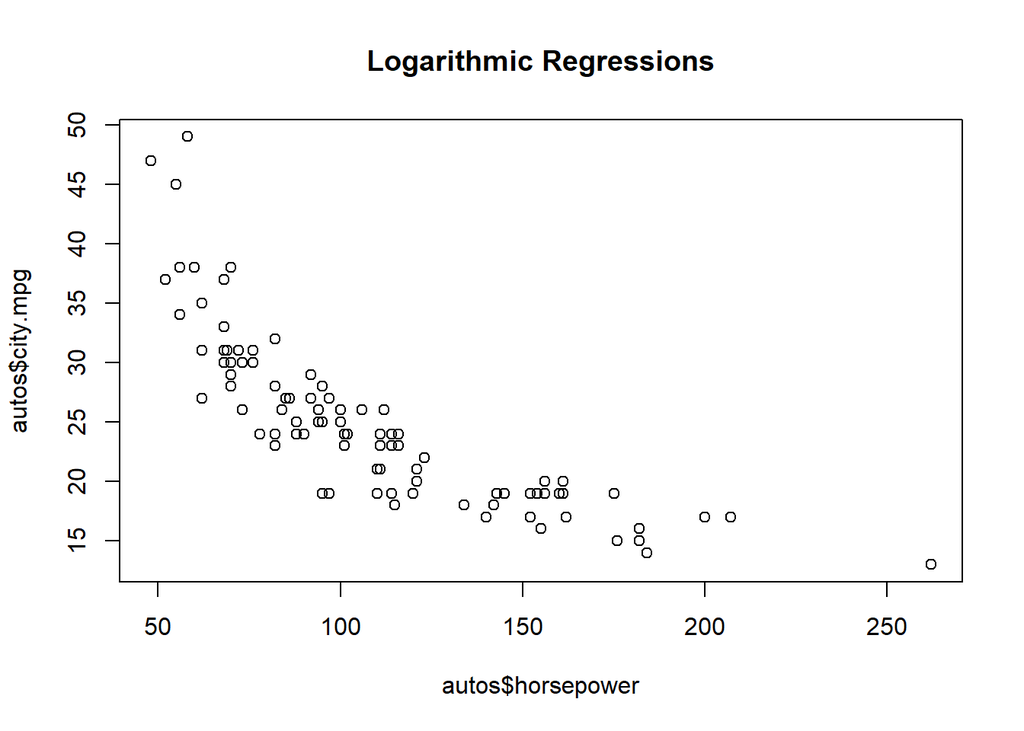

```r
plot(autos$horsepower, autos$city.mpg, main="Logarithmic Regressions")
```

**Linear-log mode**

```r
model_log <-  lm(city.mpg ~ log(horsepower),data=autos)
summary(model_log)
```

```
##
## Call:
## lm(formula = city.mpg ~ log(horsepower), data = autos)
##
## Residuals:
##     Min      1Q  Median      3Q     Max
## -6.7491 -1.7312 -0.1621  1.2798 15.0499
##
## Coefficients:
##                 Estimate Std. Error t value Pr(>|t|)
## (Intercept)     101.4362     2.8703   35.34   <2e-16 ***
## log(horsepower) -16.6204     0.6251  -26.59   <2e-16 ***
## ---
## Signif. codes:  0 '***' 0.001 '**' 0.01 '*' 0.05 '.' 0.1 ' ' 1
##
## Residual standard error: 2.954 on 191 degrees of freedom
## Multiple R-squared:  0.7873, Adjusted R-squared:  0.7862
## F-statistic:   707 on 1 and 191 DF,  p-value: < 2.2e-16
```

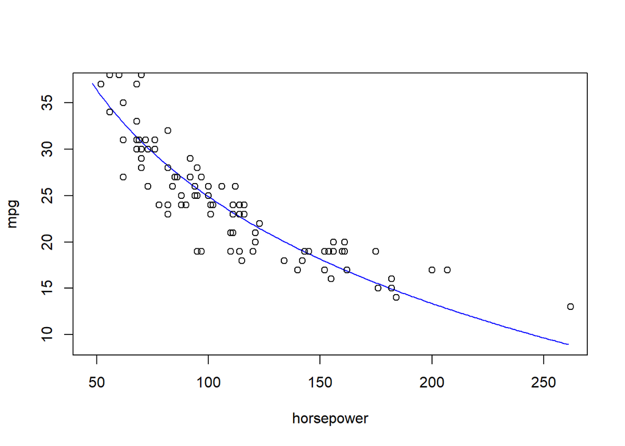

```r
series = seq(48, 261,by=1)

plot(series, predict(model_log, data.frame(horsepower=series)), col='blue', type ='l', lty=1, xlab="horsepower", ylab = "mpg")
points(autos$horsepower,autos$city.mpg)
```

**Log-linear models**

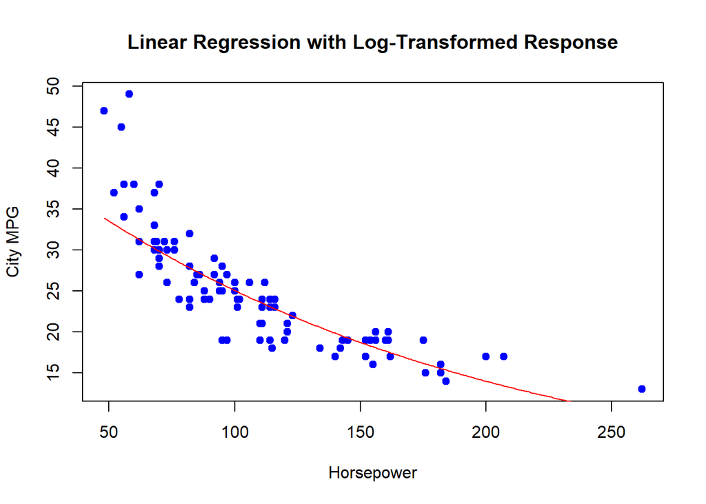

```r
# Fit a linear regression model with a log-transformed response variable
model_log1 <- lm(log(city.mpg) ~ horsepower, data = autos)

# Generate a sequence of horsepower values
series <- seq(48, 261, by = 1)

# Predict log(city.mpg) for the sequence of horsepower values
predictions <- predict(model_log1, newdata = data.frame(horsepower = series))

# Create a plot
# Create a plot
plot(autos$horsepower, autos$city.mpg, xlab = "Horsepower", ylab = "City MPG", col = 'blue', pch = 19, main = "Linear Regression with Log-Transformed Response")

# Add the linear regression line
lines(series, exp(predictions), col = 'red', lty = 1)
```

```r
# Transform the y-axis back to the original scale for visualization
#axis(2, at = pretty(autos$city.mpg), labels = round(exp(pretty(log(autos$city.mpg))), 2))
```

**Log-log models**

```r
model_log2 <-lm(log(city.mpg) ~ log(horsepower),data=autos)
summary(model_log2)
```

```
##
## Call:
## lm(formula = log(city.mpg) ~ log(horsepower), data = autos)
##
## Residuals:
##      Min       1Q   Median       3Q      Max
## -0.27347 -0.05606  0.00095  0.05634  0.34194
##
## Coefficients:
##                 Estimate Std. Error t value Pr(>|t|)
## (Intercept)      6.28168    0.09764   64.33   <2e-16 ***
## log(horsepower) -0.67278    0.02126  -31.64   <2e-16 ***
## ---
## Signif. codes:  0 '***' 0.001 '**' 0.01 '*' 0.05 '.' 0.1 ' ' 1
##
## Residual standard error: 0.1005 on 191 degrees of freedom
## Multiple R-squared:  0.8398, Adjusted R-squared:  0.8389
## F-statistic:  1001 on 1 and 191 DF,  p-value: < 2.2e-16
```

#Nonparametric Regression Models

**Locally Weighted Regression**

-Locally Weighted Regression (often abbreviated as Loess) is a non-parametric regression method that fits a smooth curve through data points.

-The curve is flexible and adapts to the data by giving more weight to nearby data points and less weight to more distant points.

-In R, ywe can perform Loess regression using the loess() function. Here’s how to do it:

```r
# Fit a loess regression model
loess_model <- loess(city.mpg ~ horsepower,data=autos)
loess_model
```

```
## Call:
## loess(formula = city.mpg ~ horsepower, data = autos)
##
## Number of Observations: 193
## Equivalent Number of Parameters: 5.37
## Residual Standard Error: 2.673
```

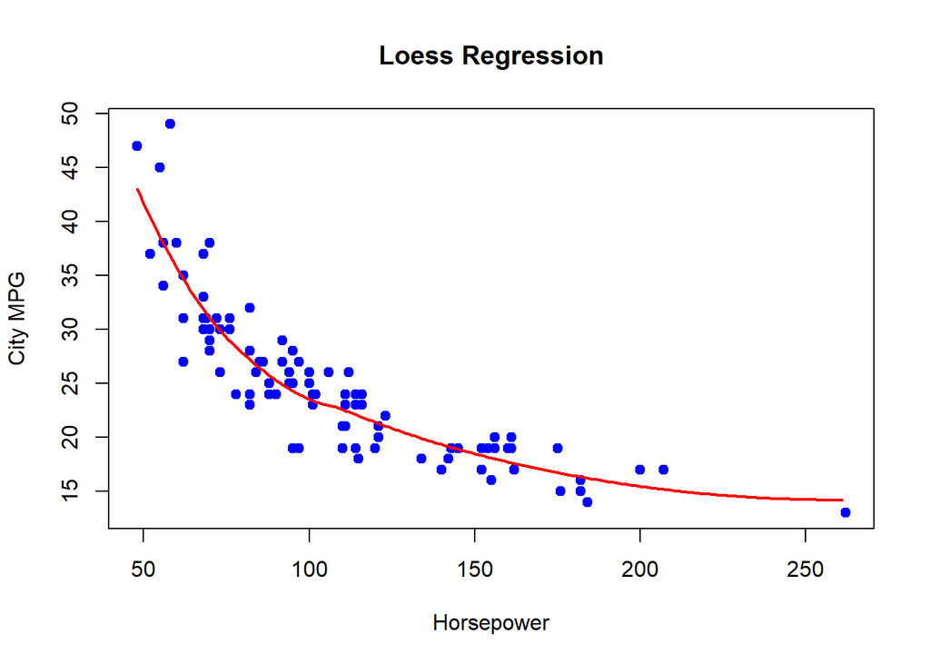

```r
# Generate a sequence of horsepower values
series = seq(48, 261,by=1)
# Predict city.mpg using the loess model
predictions_loess <- predict(loess_model, data.frame(horsepower = series))

# Create a scatterplot of the data
plot(autos$horsepower, autos$city.mpg, xlab = "Horsepower", ylab = "City MPG", pch = 19, col = "blue", main = "Loess Regression")

# Add the Loess regression curve to the plot
lines(series, predictions_loess, col = "red", lwd = 2)
```

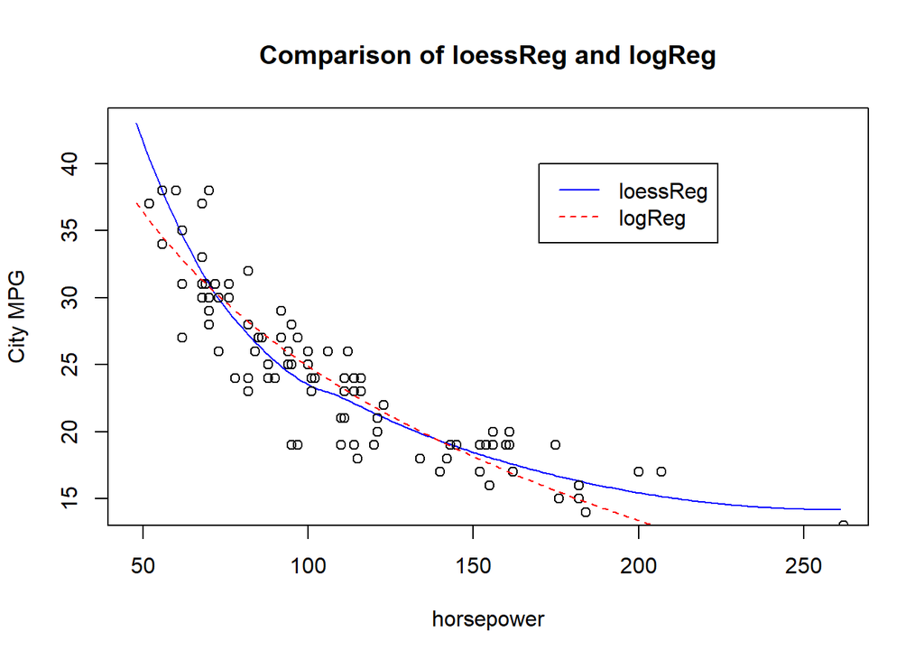

```r
# Fit a loess regression model
loessReg = loess(city.mpg ~ horsepower,data=autos)
# Fit a linear regression model with a log-transformed predictor
logReg = lm(city.mpg ~ log(horsepower),data=autos)
# Generate a sequence of horsepower values
series = seq(48, 261,by=1)
# Predict city.mpg using the loess model
predictions_loess <- predict(loessReg, data.frame(horsepower = series))
# Predict city.mpg using the linear model with a log-transformed predictor
predictions_logReg <- predict(logReg, data.frame(horsepower = series))
# Create a plot
plot(series,predictions_loess , col='blue', type ='l', lty=1, xlab="horsepower", ylab = "City MPG", pch = 19,main = "Comparison of loessReg and logReg")
points(autos$horsepower,autos$city.mpg)
lines(series,predictions_logReg , col='red', lty=2)
legend(170, 40,  legend = c("loessReg", "logReg"), col=c('blue', 'red'), lty=1:2)
```

**Change the span parameter**

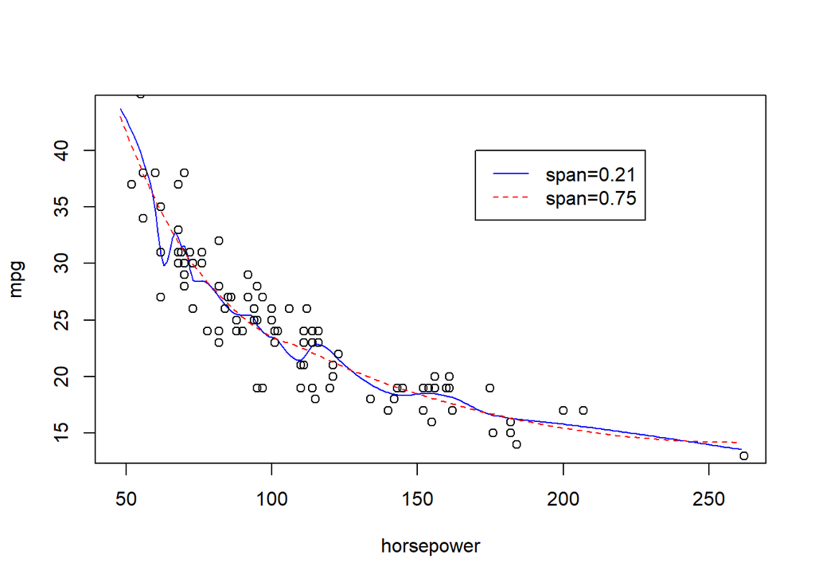

```r
loessReg1 = loess(city.mpg ~ horsepower, span=0.21,data=autos)
loessReg2 = loess(city.mpg ~ horsepower, span=0.75,data=autos)
series=seq(48, 261)
plot(series, predict(loessReg1, data.frame(horsepower=series)), col='blue', type ='l', lty=1, xlab="horsepower", ylab = "mpg")
points(autos$horsepower,autos$city.mpg)
lines(series, predict(loessReg2, data.frame(horsepower=series)), col='red', lty=2)
legend(170, 40, legend = c("span=0.21", "span=0.75"), col=c('blue', 'red'), lty=1:2)
```

**Kernel Regression**

[figure not shown]

```r
# Perform kernel regression
ks_model <- ksmooth(autos$city.mpg, autos$horsepower, "normal", 1)
# Create a scatterplot of the original data
plot(autos$city.mpg, autos$horsepower, xlab = 'Horsepower', ylab = 'City MPG', main="kernel regression")

# Overlay the kernel regression curve on the plot
lines(ks_model$x, ks_model$y, type = 'l', col = 'red', lwd = 3)
```

**Reading another dataset**

*pre-process*

```r
credit <- read.csv('Credit.csv')
dim(credit)
```

```
## [1] 400  12
```

```r
head(credit)
```

```
##   ID  Income Limit Rating Cards Age Education Gender Student Married Ethnicity
## 1  1  14.891  3606    283     2  34        11   Male      No     Yes Caucasian
## 2  2 106.025  6645    483     3  82        15 Female     Yes     Yes     Asian
## 3  3 104.593  7075    514     4  71        11   Male      No      No     Asian
## 4  4 148.924  9504    681     3  36        11 Female      No      No     Asian
## 5  5  55.882  4897    357     2  68        16   Male      No     Yes Caucasian
## 6  6  80.180  8047    569     4  77        10   Male      No      No Caucasian
##   Balance
## 1     333
## 2     903
## 3     580
## 4     964
## 5     331
## 6    1151
```

```r
str(credit)
```

```
## 'data.frame':    400 obs. of  12 variables:
##  $ ID       : int  1 2 3 4 5 6 7 8 9 10 ...
##  $ Income   : num  14.9 106 104.6 148.9 55.9 ...
##  $ Limit    : int  3606 6645 7075 9504 4897 8047 3388 7114 3300 6819 ...
##  $ Rating   : int  283 483 514 681 357 569 259 512 266 491 ...
##  $ Cards    : int  2 3 4 3 2 4 2 2 5 3 ...
##  $ Age      : int  34 82 71 36 68 77 37 87 66 41 ...
##  $ Education: int  11 15 11 11 16 10 12 9 13 19 ...
##  $ Gender   : chr  " Male" "Female" " Male" "Female" ...
##  $ Student  : chr  "No" "Yes" "No" "No" ...
##  $ Married  : chr  "Yes" "Yes" "No" "No" ...
##  $ Ethnicity: chr  "Caucasian" "Asian" "Asian" "Asian" ...
##  $ Balance  : int  333 903 580 964 331 1151 203 872 279 1350 ...
```

```r
credit=credit[,-1]
```

*Decision tree* -Decision tree is a type of supervised learning algorithm that can be used in both regression and classification problems. It works for both categorical and continuous input and output variables.

-If the response variable is continuous then we can build regression trees and if the response variable is categorical then we can build classification trees.

*Regression tree*

#Step 1: splitting data into a training set and a testing set.

```r
selected <- sample(1:dim(credit)[1], size=round(dim(credit)[1]*0.7))  #splitting the data into Train and test dataset
round(dim(credit)[1]*0.7)
```

```
## [1] 280
```

```r
train <- credit[selected,]   # 70% t which means Randomly select 280 observations for Traning set
test <- credit[-selected,]   # 30% which means Randomly select 120 observations for Traning set
```

#Step 2: Load the necessary packages.

```r
# Install packages "rpart", "rpart.plot" first, then load them into R
#install.packages('rpart')
library(rpart)
#install.packages('rpart.plot')
library(rpart.plot)
```

#Step 3: Build the initial regression tree. -First, we’ll build a large initial regression tree. We can ensure that the tree is large by using a small value for cp,

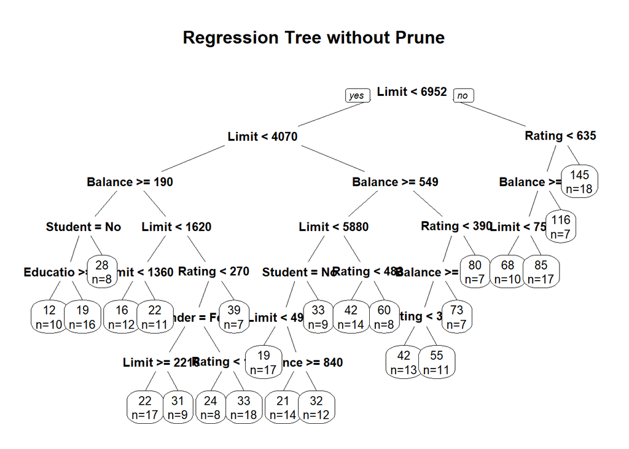

```r
# Grow regression trees
# arguments:
# cp: complexity parameter is the tuning parameter in CART.
#Any split that does not decrease the overall lack of fit by
# a factor of cp is not attempted.
# Used to choose depth of the tree, we'll manually prune the tree later and
# hence can set the threshold very low.
# method: "anova" for regression tree, "class" for classification tree

#Fitting the model
fittree <- rpart(Income~., data=train, method="anova", cp=10^(-5))
prp(fittree, faclen=-3, extra=1, cex=.8, main="Regression Tree without Prune")
```

```r
# Display the CP table
printcp(fittree)
```

```
##
## Regression tree:
## rpart(formula = Income ~ ., data = train, method = "anova", cp = 10^(-5))
##
## Variables actually used in tree construction:
## [1] Balance   Education Gender    Limit     Rating    Student
##
## Root node error: 382946/280 = 1367.7
##
## n= 280
##
##            CP nsplit rel error  xerror     xstd
## 1  0.61038292      0  1.000000 1.00777 0.125197
## 2  0.10736014      1  0.389617 0.40902 0.044412
## 3  0.04342215      2  0.282257 0.31702 0.036002
## 4  0.02281456      4  0.195413 0.26115 0.029124
## 5  0.02088029      5  0.172598 0.24112 0.025817
## 6  0.01047788      6  0.151718 0.20614 0.023323
## 7  0.00885216      7  0.141240 0.20758 0.022725
## 8  0.00488484      8  0.132388 0.20650 0.022794
## 9  0.00455932      9  0.127503 0.19480 0.021333
## 10 0.00406197     10  0.122944 0.19237 0.021149
## 11 0.00274190     12  0.114820 0.18193 0.020892
## 12 0.00210491     13  0.112078 0.18275 0.020805
## 13 0.00209531     14  0.109973 0.17838 0.019891
## 14 0.00173569     15  0.107878 0.17972 0.019806
## 15 0.00153697     16  0.106142 0.18077 0.019757
## 16 0.00106957     18  0.103068 0.18325 0.019683
## 17 0.00105128     20  0.100929 0.18268 0.019681
## 18 0.00082106     21  0.099877 0.18134 0.019543
## 19 0.00057053     22  0.099056 0.18209 0.019612
## 20 0.00001000     23  0.098486 0.18232 0.019638
```

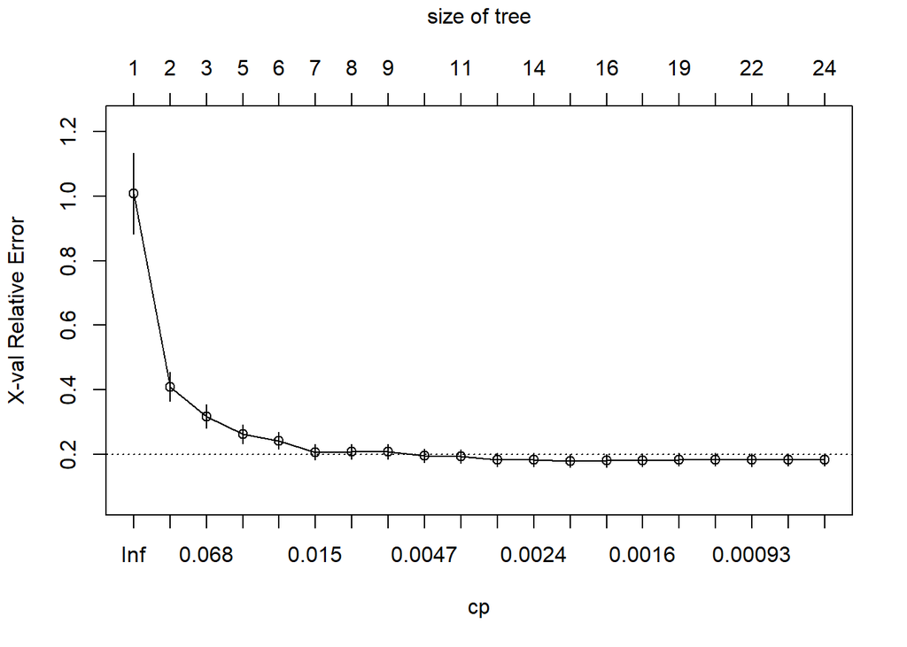

```r
# Visualize cross-validation results((xerror))
plotcp(fittree)
```

*Note:-*Selecting the value of the complexity parameter (CP) is an important step in building a decision tree model. The optimal value of the CP determines the size and complexity of the tree, and can affect the model’s performance on the testing data.

-select the optimal CP value is to identify the CP value that results in the smallest cross-validation error rate (xerror)

#Step 4: Prune the tree using the best cp (i.e., the cp with the smallest cross-validation error (xerror))

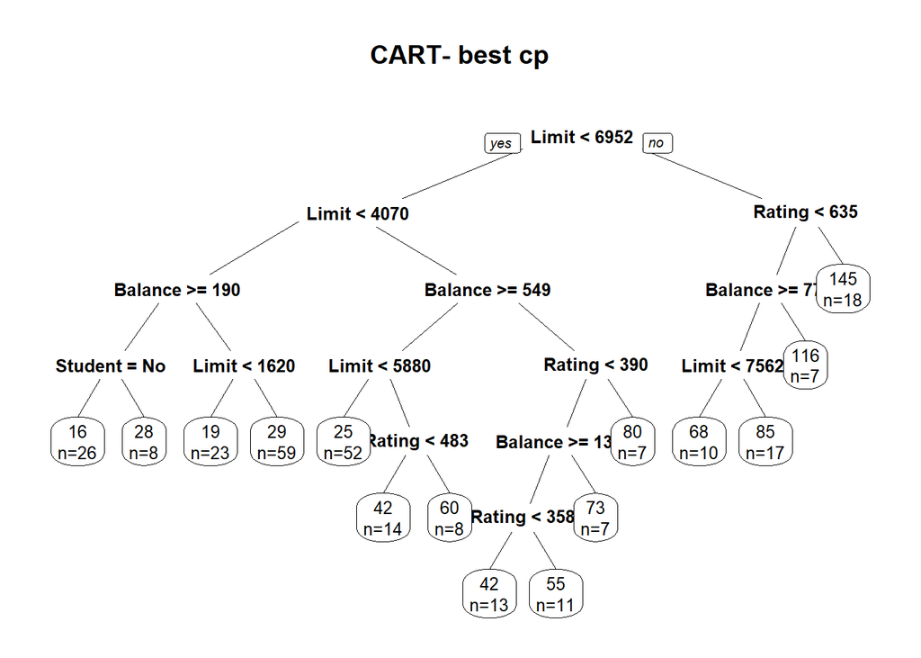

```r
#identify best cp value to use
bestcp <- fittree$cptable[which.min(fittree$cptable[,"xerror"]),"CP"]
fittreebest <- prune(fittree, cp=bestcp)
# Plot tree using package rpart.plot
prp(fittreebest, faclen=-3, extra=1, cex=.8, main="CART- best cp")
```

```r
# Exporting the results of fittreebest
# frame is a matrix with 1 row per node of the tree
# row name corresponds to a unique node index
# var - name of the variable used in the split, or <leaf>
# n - number of observations reaching the node
# yval - the fitted outcome value at the node
fittreebest$frame
```

```
##        var   n  wt         dev      yval   complexity ncompete nsurrogate
## 1    Limit 280 280 382946.4683  46.17866 0.6103829191        4          3
## 2    Limit 228 228  80403.9448  32.38037 0.0434221533        4          5
## 4  Balance 116 116  13421.5540  24.19247 0.0040619668        4          3
## 8  Student  34  34   2857.7334  19.19603 0.0021049092        4          3
## 16  <leaf>  26  26    783.7174  16.49515 0.0008210595        0          0
## 17  <leaf>   8   8   1267.9485  27.97388 0.0000100000        0          0
## 9    Limit  82  82   9363.0910  26.26417 0.0040619668        4          3
## 18  <leaf>  23  23    641.3073  18.53370 0.0005705270        0          0
## 19  <leaf>  59  59   6811.4816  29.27775 0.0020953142        0          0
## 5  Balance 112 112  51150.9928  40.86069 0.0434221533        4          3
## 10   Limit  74  74  19150.4581  31.92234 0.0228145557        4          3
## 20  <leaf>  52  52   5210.9625  24.85479 0.0017356870        0          0
## 21  Rating  22  22   5202.7421  48.62745 0.0045593179        4          4
## 42  <leaf>  14  14   1657.0236  41.89321 0.0000100000        0          0
## 43  <leaf>   8   8   1799.7438  60.41238 0.0000100000        0          0
## 11  Rating  38  38  14575.2121  58.26695 0.0104778763        4          1
## 22 Balance  31  31   7594.2535  53.38400 0.0088521610        4          4
## 44  Rating  24  24   2741.9836  47.73650 0.0027419004        4          5
## 88  <leaf>  13  13   1105.4520  41.65215 0.0000100000        0          0
## 89  <leaf>  11  11    586.5306  54.92709 0.0000100000        0          0
## 45  <leaf>   7   7   1462.3660  72.74686 0.0000100000        0          0
## 23  <leaf>   7   7   2968.4929  79.89143 0.0000100000        0          0
## 3   Rating  52  52  68798.5403 106.67888 0.1073601439        4          5
## 6  Balance  34  34  18057.1708  86.21982 0.0208802931        4          0
## 12   Limit  27  27   8048.0586  78.41137 0.0048848361        4          4
## 24  <leaf>  10  10   1060.7915  67.55870 0.0000100000        0          0
## 25  <leaf>  17  17   5116.6364  84.79529 0.0000100000        0          0
## 13  <leaf>   7   7   2013.0777 116.33814 0.0000100000        0          0
## 7   <leaf>  18  18   9628.1815 145.32378 0.0000100000        0          0
```

#Step 5: Use the tree to make predictions.

```r
predtreebest <- predict(fittreebest, test)
# root mean square error (RMSE) of the prediction
sqrt(sum((test$Income-predtreebest)^2))
```

```
## [1] 172.7822
```

*Random Forest For regression trees*

-Random Forest approach is a supervised learning algorithm. It builds the multiple decision trees which are known as forest and glue them together to urge a more accurate and stable prediction.

```r
#install.packages('randomForest')
library(randomForest)
# Do random forests
#  arguments:
#   Instead of specifying method="anova" as with rpart,
#   if the response is a factor, classification is assumed,
#   otherwise regression is assumed.
#   importance=TRUE argument allows us to inspect variable importance
#   ntree: number of bootstrap trees to grow
#   mtry: number of variables randomly sampled as candidates at each split.
#         Note that the default values are different for classification (sqrt(p)) and
#         regression (p/3)
fittreer <- randomForest(Income~., data=train, importance=T, ntree=2000, mtry=4)
print(fittreer)
```

```
##
## Call:
##  randomForest(formula = Income ~ ., data = train, importance = T,      ntree = 2000, mtry = 4)
##                Type of random forest: regression
##                      Number of trees: 2000
## No. of variables tried at each split: 4
##
##           Mean of squared residuals: 190.9648
##                     % Var explained: 86.04
```

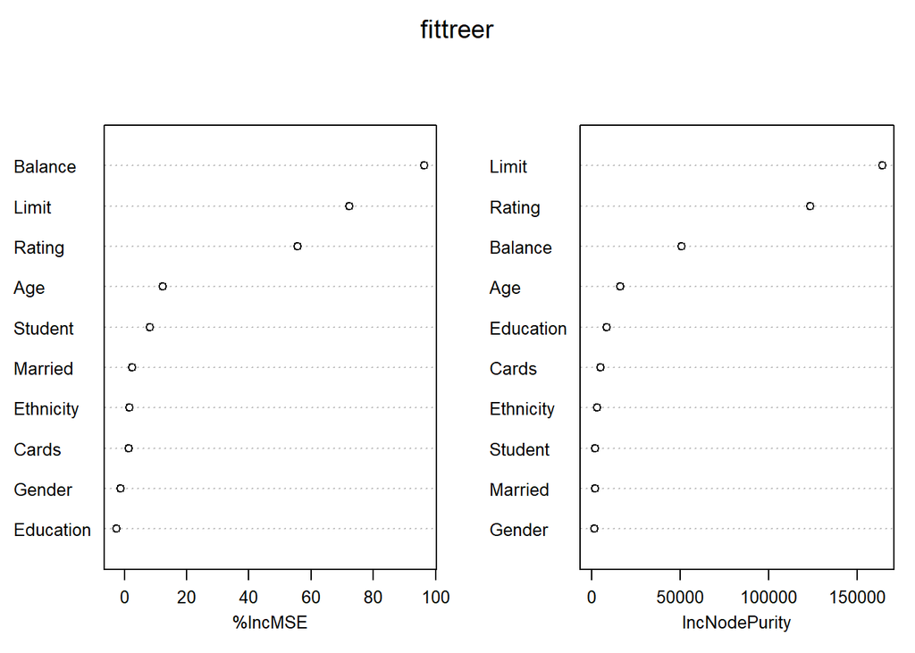

```r
# Look at what variables were important
varImpPlot(fittreer, cex=.8) #Variables with higher importance values are considered more important in predicting the response variable.
```

```r
importance(fittreer,scale=TRUE)
```

```
##             %IncMSE IncNodePurity
## Limit     72.361496    164030.162
## Rating    55.738640    123247.686
## Cards      1.432028      4955.215
## Age       12.283801     16077.111
## Education -2.545194      8209.755
## Gender    -1.214686      1534.439
## Student    8.045153      1968.326
## Married    2.554271      1652.733
## Ethnicity  1.479166      3056.404
## Balance   96.323032     50782.714
```

```r
#Predicting the variable using the test dataset
predtreer <- predict(fittreer, test)
# root mean square error (RMSE) of the prediction
sqrt(sum((test$Income-predtreer)^2))
```

```
## [1] 147.2967
```

#Advantages of Random Forest:

-Efficient: Random forests are much more efficient than decision trees while performing on large databases.

-Highly accurate: Random forests are highly accurate as they are collection of decision trees and each decision tree draws sample random data and in result, random forests produces higher accuracy on prediction.

-Efficient estimates of the test error: It makes efficient use of all predictive features and maintains accuracy even if the data is missing.

#Disadvantages of Random Forest:-

-Requires different number of levels:

-Requires a lot of memory: